# EGRMGMT 590.21 Homework 6 (Questions)

### Exercise 8 (10 Points)

- Based on the ARIMA model developed in Exercise 6, create a plot of the log-transformed sales.ts, its forecasts for the next 36 months, and the corresponding prediction intervals (at 90% confidence level) for the next 36 months

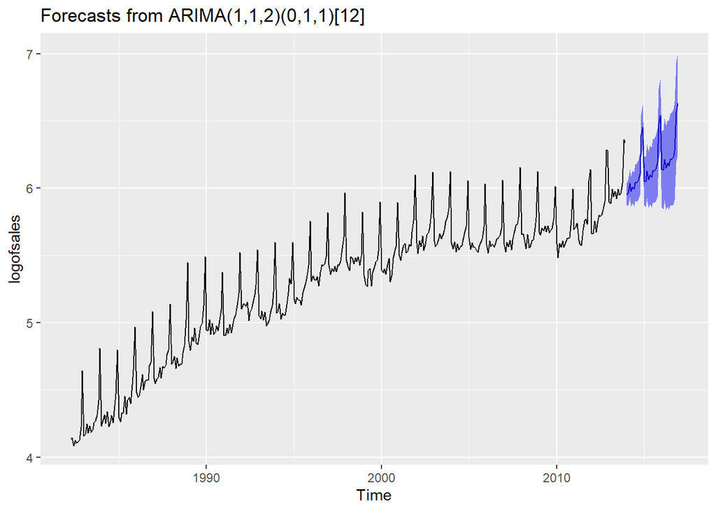

```r
autoplot(forecast(arimamodelq6,h = 36, level = 0.9))
```

### Exercise 9 (10 Points)

- Read the weekly sales data of a movie from “movie.xlsx” and develop a Bass model to predict the incremental weekly sales
- What are the optimal values for the Bass mode parameters respectively (i.e., m, p, and q)? [Hint: apply the nls() function to estimate the optimal parameters]

```r
movie.df <- read_excel("movie.xlsx")

movie_weekq9 <- movie.df$week
movie_salesq9 <- movie.df$sales
totalsales <- sum(movie_salesq9)
bass.model <- nls(movie_salesq9~M*((P+Q)^2/P)*exp(-(P+Q)*movie_weekq9)/(1+(Q/P)*exp(-(P+Q)*movie_weekq9))^2, start=list(M=totalsales, P=0.03, Q=0.38))
summary(bass.model)
```

```
##
## Formula: movie_salesq9 ~ M * ((P + Q)^2/P) * exp(-(P + Q) * movie_weekq9)/(1 +
##     (Q/P) * exp(-(P + Q) * movie_weekq9))^2
##
## Parameters:
##    Estimate Std. Error t value Pr(>|t|)
## M 1.111e+07  4.791e+05  23.180 1.09e-10 ***
## P 3.236e-02  4.496e-03   7.198 1.76e-05 ***
## Q 5.307e-01  3.980e-02  13.335 3.91e-08 ***
## ---
## Signif. codes:  0 '***' 0.001 '**' 0.01 '*' 0.05 '.' 0.1 ' ' 1
##
## Residual standard error: 128900 on 11 degrees of freedom
##
## Number of iterations to convergence: 10
## Achieved convergence tolerance: 2.381e-06
```

### Exercise 10 (10 Points)

- Based on the Bass model developed in Exercise 9, create a multi-line chart for the historical weekly sales of the past 14 weeks, its model-based predicted values in the observed 14 weeks and the next 3 weeks